# Research Methods in Political Science II

Day 2-2: Introduction to Stan

Yuki Yanai

November 5, 2016

# Preparation

Load some packages.

```r
library('coefplot')
library('rethinking')
library('ggmcmc')
```

# Fitting a Normal Linear Model in Different Ways

## Data generation

First, let’s create a fake data set we are analyzing today.

```r
set.seed(2016-11-05)
n <- 50
true_beta <- c(2, 0.2, 1.5, -2)
true_sigma <- 3
x2 <- runif(n, min = 1, max = 10)
x3 <- rnorm(n, mean = 0, sd = 4)
x4 <- runif(n, min = -10, max = 10)
y <- true_beta[1] + true_beta[2] * x2 + true_beta[3] * x3 +
  true_beta[4] * x4 + rnorm(n, mean = 0, sd = true_sigma)
dd <- data.frame(y = y, x2 = x2, x3 = x3, x4 = x4)
```

## Statistical Model

We have the outcome $y$ and three explanatory variables $x_2$, $x_3$, and $x_4$. Suppose we believe for theoretical reasons that the outcome $y$ is generated by the following mechanism.
$$y_i \sim \mbox{Normal}(\mu_i, \sigma^2),$$
$$\mu_i = \beta_1 + \beta_2 x_2 + \beta_3 x_3 + \beta_4 x_4,$$
$$\beta_p \sim \mbox{Normal}(0, 100^2),$$
$$\sigma \sim \mbox{Uniform}(0, 100).$$

## Fit the model by lm()

Since the prior are non-informative in the model, we can use `lm()` to estimate $\beta$s.

```r
fit_1 <- lm(y ~ x2 + x3 + x4, data = dd)
summary(fit_1)
```

```
##
## Call:
## lm(formula = y ~ x2 + x3 + x4, data = dd)
##
## Residuals:
##    Min     1Q Median     3Q    Max
## -6.877 -1.934 -0.183  2.434  5.976
##
## Coefficients:
##             Estimate Std. Error t value Pr(>|t|)
## (Intercept)  3.11688    1.05534   2.953  0.00494
## x2           0.07788    0.16540   0.471  0.63995
## x3           1.50223    0.13465  11.156 1.12e-14
## x4          -2.05099    0.08643 -23.729  < 2e-16
##
## Residual standard error: 3.24 on 46 degrees of freedom
## Multiple R-squared:  0.9304, Adjusted R-squared:  0.9259
## F-statistic: 204.9 on 3 and 46 DF,  p-value: < 2.2e-16
```

Let’s visualize the result with `coefplot()`.

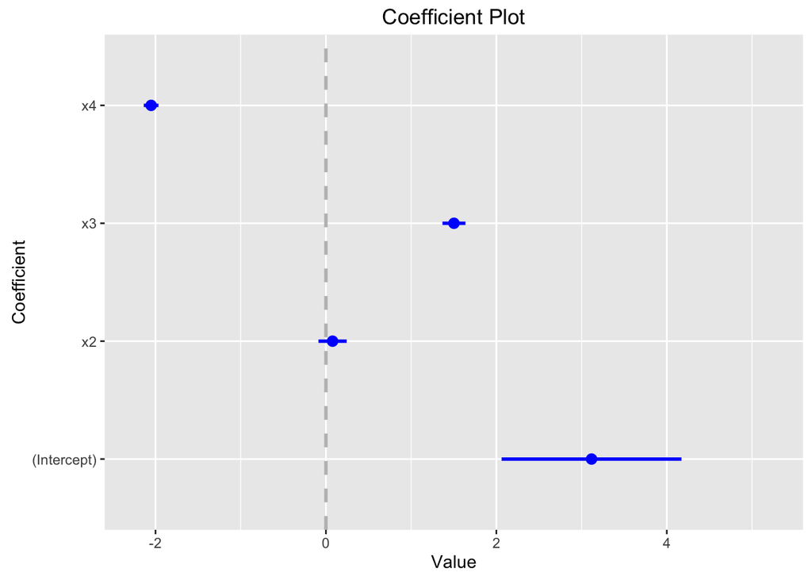

```r
coefplot(fit_1, intercept = TRUE)
```

## Fit the model by map()

Alternatively, we can use `rethinking::map()`, which has been our favorite method so far.

```r
map_model <- alist(
    y ~ dnorm(mu, sigma),
    mu <- b1 + b2*x2 + b3*x3 + b4*x4,
    b1 ~ dnorm(0, 100),
    b2 ~ dnorm(0, 100),
    b3 ~ dnorm(0, 100),
    b4 ~ dnorm(0, 100),
    sigma ~ dunif(0, 100)
)
fit_2 <- map(map_model, data = dd)
precis(fit_2)
```

```
##        Mean StdDev  5.5% 94.5%
## b1     3.12   1.01  1.50  4.73
## b2     0.08   0.16 -0.18  0.33
## b3     1.50   0.13  1.30  1.71
## b4    -2.05   0.08 -2.18 -1.92
## sigma  3.11   0.31  2.61  3.60
```

```r
#plot(precis(fit_2))
```

Thesre estimates were obtained by quadratic approximation.

## Fit the model by Stan

### Indirectly call RStan with map2sta()

Now, let’s fit the model with RStan. We can feed the same model we used for `map()`.

Here, we run 4 chains. We sample 2,000 values in each chain, and discard 1,000 values in each as warm-up. As a result, we will get 4,000 smaple values. Since each chain samples values independently from each other, we can simulate chains in parallel if the computer has multiple cores. Below, we specify the number of cores we use in parallel by **core** argument.

```r
fit_3 <- map2stan(map_model, data = dd, cores = parallel::detectCores(),
                  chains = 4, iter = 2000, warmup = 1000)
```

[output not shown]

[output cut: 13 more lines]

[output not shown]

```r
precis(fit_3)
```

```
##        Mean StdDev lower 0.89 upper 0.89 n_eff Rhat
## b1     3.11   1.05       1.43       4.78  2100    1
## b2     0.08   0.17      -0.21       0.32  2066    1
## b3     1.50   0.14       1.28       1.71  2842    1
## b4    -2.05   0.09      -2.19      -1.92  2560    1
## sigma  3.33   0.34       2.77       3.84  2483    1
```

Compare this result to the result of **fit_2**. In fit_2, the fourth and fifth columns show the values for 5.5 and 94.5 percentiles, respectively, In contrast, this result shows the lower and upper bound of the 89% HPDI (highest posterior density interval). In this example, they don’t differ much. But if the posterior is far from normal, quadratic approximation doesn’t work well, and the percentiles can differ a lot from the HPDI.

### Use RStan directly

We have learned `map2stan()` is very convenient. For a simple model like this, we can instantly get the estimates by `map2stan()`. However, it is better to know how to use RStan itself without **rethinking** packages because it gives us more felxibility.

When use RStan, we should specify a model in a seprate file with the extention **.stan**. Every Stan model has to have three blocks: **data**, **parameters**, and **model**. In addition to them, it can have **transformed parameters** and **generated quantities** blocks.

Let’s translate our model into Stan and save it as the file named **d2-model1.stan** in the **stan-models/** folder. RStudio helps you write a Stan model by highliting functions.

```r
data {
    int<lower=0> N;
    real Y[N];
    real X2[N];
    real X3[N];
    real X4[N];
}

parameters {
    real beta[4];
    real<lower=0> sigma;
}

transformed parameters {
    real mu[N];
    for (n in 1:N) {
        mu[n] = beta[1] + beta[2]*X2[n] + beta[3]*X3[n] + beta[4]*X4[n];
    }
}

model {
    for (n in 1:N) {
        Y[n] ~ normal(mu[n], sigma);
    }
    for (p in 1:4) {
        beta[p] ~ normal(0, 100);
    }
    sigma ~ uniform(0, 100);
}
```

Could you tell the differece between the Stan model and the map model?

Now, let’s fit the model. We use `rstan::stan()` function. But before that, if the computer has a multi-core processor, it is faster to run the simulation in parallel. To do so, set

```r
options(mc.cores = parallel::detectCores())
```

And we need to pass a list of data.

```r
dd1 <- list(N = nrow(dd), Y = dd$y, X2 = dd$x2, X3 = dd$x3, X4 = dd$x4)
```

Now, we’re rady.

```r
fit_4 <- stan(file = 'stan-models/d2-model1.stan', data = dd1,
              chains = 4, iter = 2000, warmup = 1000)
```

[output not shown]

As you probably noticed, it takes time to compile to a Stan model. We sometimes wanna re-fit the model without compiling the same model again. For that purpose, we can separate the compiling phrse from the sampling phase. First, comile the model by ``rsta::stan_model()`.

```r
stan_m1 <- stan_model('stan-models/d2-model1.stan')
```

Then, sample the posterior by `rstan::sampling()`.

```r
fit_4 <- sampling(stan_m1, data = dd1, seed = 12345,
                  chains = 4, iter = 2000, warmup = 1000)
```

Let’s look at the result.

```r
print(fit_4)
```

```
## Inference for Stan model: d2-model1.
## 4 chains, each with iter=2000; warmup=1000; thin=1;
## post-warmup draws per chain=1000, total post-warmup draws=4000.
##
##           mean se_mean   sd   2.5%    25%    50%    75%  97.5% n_eff Rhat
## beta[1]   3.14    0.02 1.04   1.11   2.43   3.12   3.84   5.19  1786    1
## beta[2]   0.07    0.00 0.16  -0.24  -0.03   0.08   0.18   0.39  1816    1
## beta[3]   1.50    0.00 0.13   1.24   1.41   1.50   1.59   1.76  2995    1
## beta[4]  -2.05    0.00 0.09  -2.23  -2.11  -2.05  -1.99  -1.88  2875    1
## sigma     3.32    0.01 0.34   2.72   3.08   3.29   3.53   4.10  3070    1
## mu[1]    -7.33    0.02 0.81  -8.90  -7.88  -7.34  -6.81  -5.69  2387    1
## mu[2]    -0.95    0.01 0.87  -2.62  -1.55  -0.93  -0.36   0.76  4000    1
## mu[3]     2.66    0.02 0.98   0.72   2.01   2.68   3.31   4.61  3484    1
## mu[4]    -4.22    0.01 0.62  -5.43  -4.64  -4.21  -3.82  -2.99  3348    1
## mu[5]     6.31    0.02 0.94   4.50   5.68   6.31   6.96   8.15  3565    1
## mu[6]    -0.62    0.01 0.67  -1.90  -1.08  -0.62  -0.17   0.73  3628    1
## mu[7]   -10.43    0.02 0.96 -12.30 -11.04 -10.44  -9.78  -8.52  3086    1
## mu[8]     2.78    0.01 0.65   1.52   2.34   2.78   3.22   4.04  4000    1
## mu[9]   -14.34    0.02 0.99 -16.28 -14.99 -14.34 -13.68 -12.34  3163    1
## mu[10]   -5.93    0.01 0.70  -7.27  -6.41  -5.93  -5.47  -4.55  4000    1
## mu[11]    7.98    0.02 0.80   6.40   7.45   7.98   8.50   9.56  2049    1
## mu[12]    4.70    0.02 0.85   3.05   4.14   4.70   5.27   6.38  2237    1
## mu[13]   12.89    0.02 0.99  10.96  12.24  12.89  13.53  14.85  1954    1
## mu[14]   18.84    0.02 1.05  16.76  18.15  18.86  19.51  20.96  2135    1
## mu[15]    5.97    0.02 0.84   4.37   5.41   5.98   6.52   7.62  3010    1
## mu[16]   20.01    0.02 0.86  18.28  19.45  20.01  20.60  21.72  2978    1
## mu[17]   -9.47    0.01 0.82 -11.05 -10.02  -9.48  -8.93  -7.86  3450    1
## mu[18]   25.56    0.02 1.08  23.40  24.85  25.56  26.25  27.73  2430    1
## mu[19]   -5.30    0.01 0.85  -6.95  -5.89  -5.32  -4.74  -3.62  4000    1
## mu[20]    8.19    0.02 1.10   6.10   7.45   8.20   8.93  10.36  2806    1
## mu[21]    8.17    0.02 0.96   6.28   7.53   8.17   8.82  10.07  3052    1
## mu[22]   -2.70    0.02 1.02  -4.67  -3.41  -2.72  -2.00  -0.69  3619    1
## mu[23]  -18.25    0.02 1.07 -20.35 -18.96 -18.27 -17.53 -16.12  3196    1
## mu[24]   -0.50    0.01 0.73  -1.91  -1.01  -0.50  -0.01   0.97  4000    1
## mu[25]    9.33    0.02 0.84   7.68   8.78   9.33   9.89  10.98  3106    1
## mu[26]    4.34    0.01 0.69   3.00   3.88   4.35   4.80   5.69  4000    1
## mu[27]    9.03    0.01 0.61   7.83   8.63   9.05   9.42  10.24  4000    1
## mu[28]    1.36    0.01 0.81  -0.18   0.81   1.37   1.90   2.93  4000    1
## mu[29]  -13.82    0.02 0.87 -15.54 -14.41 -13.83 -13.24 -12.11  3241    1
## mu[30]    5.91    0.02 1.05   3.84   5.21   5.93   6.60   8.02  2727    1
```

[output cut: 11 more lines]

```
## mu[42]   12.20    0.02 1.01  10.19  11.53  12.20  12.86  14.19  2107    1
## mu[43]   -5.88    0.02 1.04  -7.86  -6.56  -5.89  -5.20  -3.82  2246    1
## mu[44]    4.40    0.02 1.21   1.98   3.58   4.41   5.18   6.81  3211    1
## mu[45]   24.03    0.02 1.02  22.09  23.33  24.04  24.73  26.04  3078    1
## mu[46]   11.76    0.01 0.65  10.44  11.33  11.77  12.18  13.06  2626    1
## mu[47]   15.58    0.01 0.89  13.88  14.97  15.57  16.20  17.30  3658    1
## mu[48]  -19.49    0.03 1.32 -22.07 -20.36 -19.49 -18.65 -16.81  2378    1
## mu[49]    5.72    0.01 0.57   4.59   5.33   5.72   6.10   6.81  4000    1
## mu[50]   21.19    0.02 1.17  18.92  20.39  21.20  21.98  23.44  3081    1
## lp__    -83.02    0.04 1.54 -86.85 -83.84 -82.70 -81.88 -80.97  1788    1
##
## Samples were drawn using NUTS(diag_e) at Fri Nov  4 16:03:13 2016.
## For each parameter, n_eff is a crude measure of effective sample size,
## and Rhat is the potential scale reduction factor on split chains (at
## convergence, Rhat=1).
```

Since Rhat is 1 for all paramters, it seems that we reached at convergence. However, if there is a parameter with Rhat > 1.01, we should sample the chains longer.

We can create some plots as follows.

```
## ci_level: 0.8 (80% intervals)
```

```
## outer_level: 0.95 (95% intervals)
```

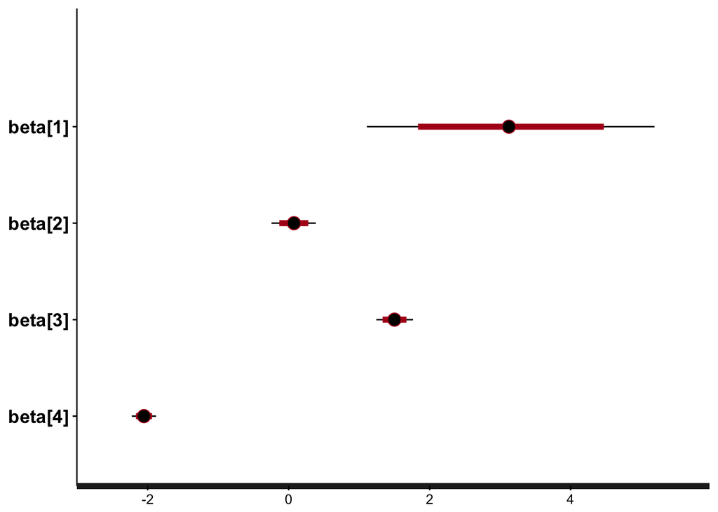

```r
plot(fit_4, pars = 'beta')
```

Let’s make a trace plot. We can use `ggmcmc::ggmcmc()`. The output is saved in the file named (d2-model1-traceplot.pdf)[output/d2-model1-traceplots] in the output folder.

```r
ggmcmc(ggs(fit_4, inc_warmup = TRUE), plot = 'traceplot',
       file = 'output/d2-model1-traceplots.pdf')
```

```
## Plotting traceplots
```

```
## Time taken to generate the report: 15 seconds.
```

You can extract the sampled values by `rstan::extract()`. Since **dplyr** package also contains the function called `extract()`, it is safer to call it with the package name.

```r
stan_sample <- rstan::extract(fit_4)
```

Let’s check some posterior distributions.

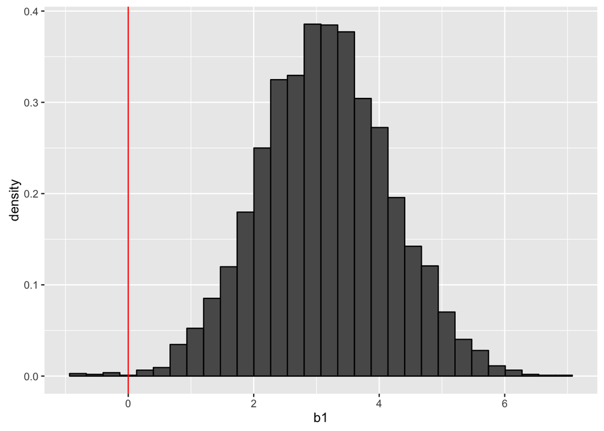

```r
df <- data.frame(b1 = stan_sample$beta[,1],
                 b2 = stan_sample$beta[,2],
                 b3 = stan_sample$beta[,3],
                 b4 = stan_sample$beta[,4])
hist_beta <- ggplot(df, aes(y = ..density..))
hist_b1 <- hist_beta + geom_histogram(aes(x = b1), color = 'black') +
    geom_vline(aes(xintercept = 0), color = 'red')
plot(hist_b1)
```

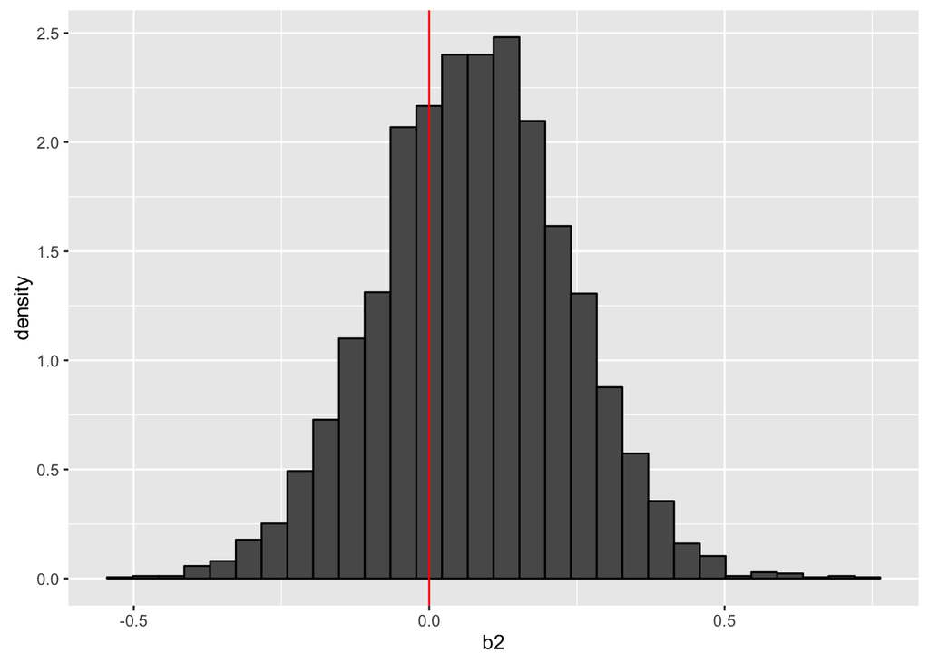

```r
hist_b2 <- hist_beta + geom_histogram(aes(x = b2), color = 'black') +
    geom_vline(aes(xintercept = 0), color = 'red')
plot(hist_b2)
```

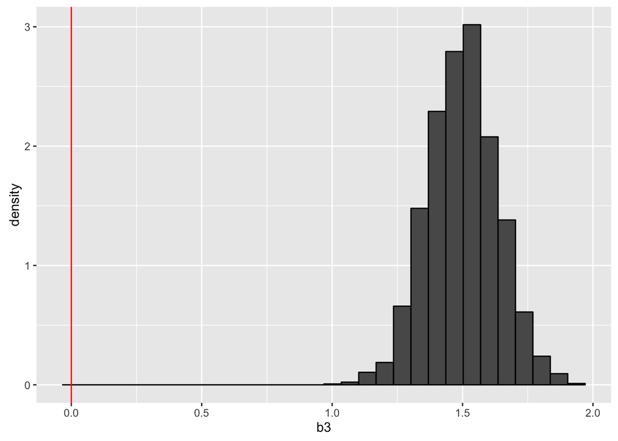

```r
hist_b3 <- hist_beta + geom_histogram(aes(x = b3), color = 'black') +
    geom_vline(aes(xintercept = 0), color = 'red')
plot(hist_b3)
```

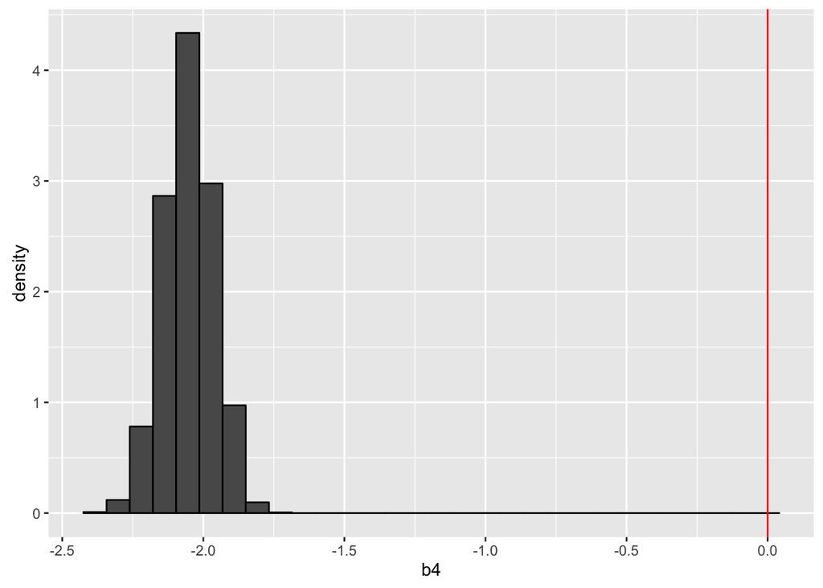

```r
hist_b4 <- hist_beta + geom_histogram(aes(x = b4), color = 'black') +
    geom_vline(aes(xintercept = 0), color = 'red')
plot(hist_b4)
```

Now let’s make a figure presenting the predicted values of y. Since we have to sample of estimates, we can calculate the predicted values. However, it is easier to ask Stan to compute the values. Let’s modify the model as follows.

```r
data {
    int<lower=0> N;
    real Y[N];
    real X2[N];
    real X3[N];
    real X4[N];
}

parameters {
    real beta[4];
    real<lower=0> sigma;
}

transformed parameters {
    real mu[N];
    for (n in 1:N) {
        mu[n] = beta[1] + beta[2]*X2[n] + beta[3]*X3[n] + beta[4]*X4[n];
    }
}

model {
    for (n in 1:N) {
        Y[n] ~ normal(mu[n], sigma);
    }
    for (p in 1:4) {
        beta[p] ~ normal(0, 100);
    }
    sigma ~ uniform(0, 100);
}

generated quantities {
    real y_pred[N];
    for (n in 1:N) {
        y_pred[n] = normal_rng(mu[n], sigma);
    }
}
```

Save this model as d2-model1b.stan in the **stan-models** folder.

We need to compile the model and sample the values.

```r
stan_m1b <- stan_model('stan-models/d2-model1b.stan')
```

[output not shown]

```r
fit_5 <- sampling(stan_m1b, data = dd1, seed = 777,
                  chains = 4, iter = 2000, warmup = 1000)
```

Check the result.

```r
print(fit_5)
```

```
## Inference for Stan model: d2-model1b.
## 4 chains, each with iter=2000; warmup=1000; thin=1;
## post-warmup draws per chain=1000, total post-warmup draws=4000.
##
##              mean se_mean   sd   2.5%    25%    50%    75%  97.5% n_eff
## beta[1]      3.14    0.02 1.07   1.12   2.43   3.11   3.84   5.30  1999
## beta[2]      0.08    0.00 0.17  -0.26  -0.03   0.08   0.19   0.40  1914
## beta[3]      1.50    0.00 0.14   1.23   1.41   1.50   1.60   1.77  2938
## beta[4]     -2.05    0.00 0.09  -2.22  -2.11  -2.05  -2.00  -1.88  2866
## sigma        3.32    0.01 0.35   2.73   3.08   3.30   3.53   4.11  2326
## mu[1]       -7.33    0.02 0.80  -8.82  -7.87  -7.34  -6.81  -5.70  2499
## mu[2]       -0.95    0.02 0.89  -2.75  -1.53  -0.94  -0.35   0.83  2933
## mu[3]        2.65    0.02 1.01   0.68   1.97   2.66   3.32   4.64  2898
## mu[4]       -4.21    0.01 0.60  -5.36  -4.62  -4.22  -3.81  -2.99  3132
## mu[5]        6.35    0.02 0.96   4.51   5.72   6.35   6.99   8.23  3381
## mu[6]       -0.62    0.01 0.68  -1.97  -1.08  -0.61  -0.15   0.73  3302
## mu[7]      -10.42    0.02 0.97 -12.36 -11.05 -10.43  -9.76  -8.53  2350
## mu[8]        2.79    0.01 0.66   1.47   2.36   2.79   3.22   4.08  3479
## mu[9]      -14.33    0.02 0.98 -16.35 -14.99 -14.35 -13.67 -12.42  2520
## mu[10]      -5.93    0.01 0.70  -7.35  -6.39  -5.93  -5.45  -4.53  3027
## mu[11]       7.98    0.02 0.82   6.42   7.43   7.97   8.52   9.63  2275
## mu[12]       4.72    0.02 0.87   3.06   4.14   4.71   5.28   6.52  2393
## mu[13]      12.91    0.02 1.01  10.96  12.24  12.88  13.57  14.90  2126
## mu[14]      18.85    0.02 1.06  16.78  18.14  18.84  19.55  20.95  2325
## mu[15]       5.99    0.02 0.85   4.28   5.43   6.00   6.56   7.67  2646
## mu[16]      20.03    0.01 0.84  18.36  19.47  20.02  20.59  21.67  3226
## mu[17]      -9.48    0.02 0.81 -11.12 -10.01  -9.48  -8.93  -7.84  2838
## mu[18]      25.59    0.02 1.06  23.53  24.88  25.57  26.30  27.63  2812
## mu[19]      -5.28    0.02 0.86  -7.00  -5.84  -5.28  -4.70  -3.57  2732
## mu[20]       8.23    0.02 1.13   6.04   7.48   8.22   8.96  10.46  2727
## mu[21]       8.21    0.02 0.98   6.28   7.55   8.20   8.87  10.16  2807
## mu[22]      -2.67    0.02 1.04  -4.67  -3.35  -2.67  -1.96  -0.63  2820
## mu[23]     -18.24    0.02 1.05 -20.32 -18.92 -18.25 -17.55 -16.19  2626
## mu[24]      -0.47    0.01 0.74  -1.88  -0.95  -0.48   0.02   0.99  4000
## mu[25]       9.37    0.02 0.85   7.68   8.80   9.36   9.93  11.05  2951
## mu[26]       4.37    0.01 0.70   3.02   3.90   4.35   4.83   5.77  3772
## mu[27]       9.04    0.01 0.61   7.84   8.65   9.04   9.44  10.20  3634
## mu[28]       1.37    0.02 0.83  -0.27   0.82   1.38   1.91   2.99  2920
## mu[29]     -13.82    0.02 0.84 -15.51 -14.39 -13.82 -13.27 -12.16  2778
## mu[30]       5.90    0.02 1.08   3.81   5.18   5.90   6.61   8.00  2552
```

[output cut: 168 more lines]

```
## y_pred[42]    1
## y_pred[43]    1
## y_pred[44]    1
## y_pred[45]    1
## y_pred[46]    1
## y_pred[47]    1
## y_pred[48]    1
## y_pred[49]    1
## y_pred[50]    1
## lp__          1
##
## Samples were drawn using NUTS(diag_e) at Fri Nov  4 16:04:24 2016.
## For each parameter, n_eff is a crude measure of effective sample size,
## and Rhat is the potential scale reduction factor on split chains (at
## convergence, Rhat=1).
```

Looking at Rhats, it looks OK.

Extract the sample.

```r
stan_sample <- rstan::extract(fit_5)
```

Now this list contains the predicted values of y. Using these values, let’s make a plot.

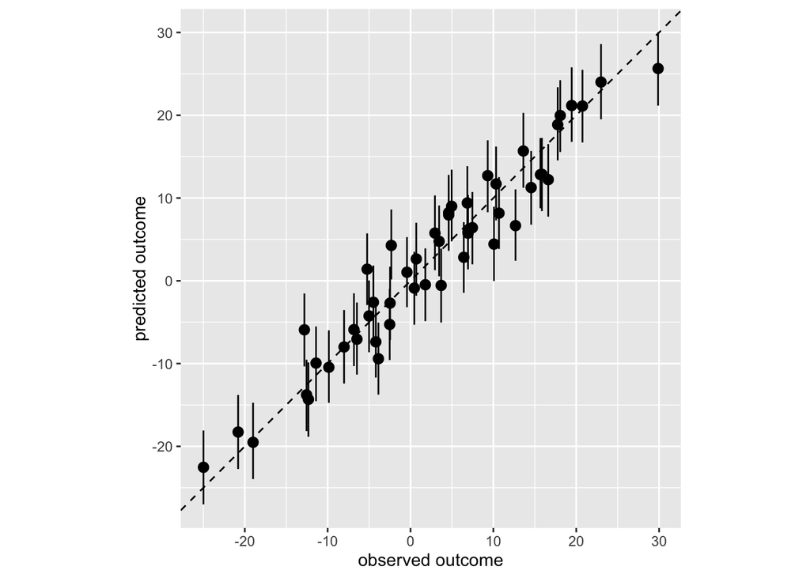

```r
d_quantiles <- t(apply(stan_sample$y_pred, 2, quantile, prob = c(.1, .5, .9)))
colnames(d_quantiles) <- c('p10', 'p50', 'p90')
d_quantiles <- data.frame(dd, d_quantiles)

p <- ggplot(d_quantiles, aes(x = y, y = p50, ymin = p10, ymax = p90)) +
    coord_fixed(ratio = 1) +
    geom_pointrange() +
    geom_abline(aes(intercept = 0, slope = 1), color = 'black', linetype = 'dashed') +
    labs(x = 'observed outcome', y = 'predicted outcome')
print(p)
```

One big advantage of Bayesian estimation is that we can calculate a variety of probabilities because we have distributions of parameters. For instance, the probability that $\beta_2$ is larger than 0 is

```r
sum(stan_sample$beta[,2] > 0) / length(stan_sample$beta[,2])
```

```
## [1] 0.67975
```

Similarly, the probability that $\sigma$ is in the interval $[2.5, 3.5]$ is

```r
sum(stan_sample$sigma >= 2.5 & stan_sample$sigma <= 3.5) / length(stan_sample$sigma)
```

```
## [1] 0.711
```

Back to Class Materials